# 경제자료분석과 예측 - #05 시계열 회귀 모형 (1)

2025년 2학기

## 시계열 회귀 모형

## 1. 개요

- 이 장에서는 **회귀모형(regression models)** 을 다룬다.
- 기본 개념은, 관심 있는 시계열 \(y\)가 다른 시계열 \(x\)들과 **선형적 관계(linear relationship)** 를 가진다고 가정하고,  
  이를 이용하여 \(y\)의 향후 값을 예측(forecast)하는 것이다.
- 수식으로 간단히 표현하면 다음과 같다.

\[ y_t = \beta_0 + \beta_1 x_{1,t} + \beta_2 x_{2,t} + \cdots + \beta_k x_{k,t} + \varepsilon_t \]

- 여기서 \(\varepsilon_t\)는 **예측오차(prediction error)** 혹은 **잔차(residual)** 를 의미한다.

## 2. 예시

- 예를 들어, 월별 매출액 \(y\)를 **총 광고비 지출** \(x\)로 예측할 수 있다.
- 또 다른 예로, 일별 전력수요 \(y\)를 **기온** \(x_1\)과 **요일** \(x_2\)를 예측변수로 사용하여 예측할 수 있다.

이처럼 회귀모형은 시계열 데이터에서 변수 간 관계를 활용하여  
미래 값을 예측하는 강력한 도구로 사용된다.

## 3. 용어 정리

- 예측하려는 변수 \(y\)는 **피회귀변수(regressand)**,  
  **종속변수(dependent variable)**, 또는 **설명되는 변수(explained variable)** 라고도 부른다.
- 예측변수들 \(x\)는 **회귀자(regressors)**,  
  **독립변수(independent variables)**, 또는 **설명변수(explanatory variables)** 라고도 한다.

이 문서에서는 혼선을 피하기 위해 다음과 같이 용어를 통일한다.

- \(y\): **예측 변수(forecast variable)**
- \(x\): **예측변수들(predictor variables)**

## 단순 선형회귀 (Simple Linear Regression)

## 단순 선형회귀

- 가장 단순한 경우, 회귀모형은 예측 변수 \(y\)와 단일 예측변수 \(x\) 사이의 **선형적 관계(linear relationship)** 를 허용한다.

\[ y_t = \beta_0 + \beta_1 x_t + \varepsilon_t \]

- 이러한 모형으로부터 생성된 인공적 데이터의 예가 다음 그림림에 제시되어 있다.
- 계수 \(\beta_0\)와 \(\beta_1\)은 각각 **절편(intercept)** 과 **기울기(slope)** 를 나타낸다.
  - 절편 \(\beta_0\)는 \(x = 0\)일 때 \(y\)의 예측값을 의미한다.
  - 기울기 \(\beta_1\)는 \(x\)가 한 단위 증가할 때 \(y\)가 평균적으로 얼마나 변하는지를 나타낸다.

## 단순 선형회귀

**단순 선형회귀모형(Simple linear regression model)** 으로부터 생성된 데이터의 예

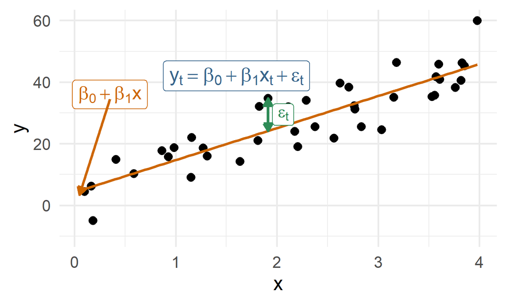

## 단순 선형회귀

- 관측값들은 직선 위에 완벽히 놓이지 않고, 그 주변에 흩어져 있는 것을 볼 수 있다.
  - 각 관측값 \(y_t\)는 다음 두 부분으로 구성된다고 생각할 수 있다.

\[ y_t = \overbrace{\beta_0 + \beta_1 x_t}^{\text{체계적 부분}} + \overbrace{\varepsilon_t}^{\text{확률적 오차}} \]

- 여기서 **오차항(error term)** \(\varepsilon_t\)는 ’실수(mistake)’를 의미하는 것이 아니라, 기저에 있는 직선모형으로부터의 **편차(deviation)** 를 뜻한다.
  - 즉, \(x_t\) 이외의 다른 요인들이 \(y_t\)에 미치는 영향을 모두 포착하는 역할을 한다.

## 미국 소비지출 예제

## 1. 데이터와 배경

- **미국의 실질 개인소비지출(Consumption, \(y\))** 과 **실질 개인 가처분소득(Income, \(x\))** 의 **분기별 증감률(%)** 자료를 이용해 단순 선형회귀를 살펴본다.
- 분석 기간은 **1970년 1분기(1970 Q1)** 부터 **2019년 2분기(2019 Q2)** 까지이다.

## 2. 미국의 개인소비지출과 가처분소득의 분기별 증감률

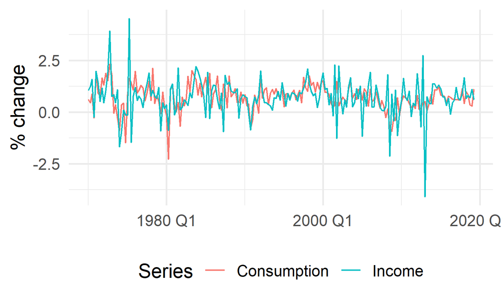

## 3. 산점도와 회귀선

- 소득 증감률에 대한 소비 증감률의 산점도를 그리고, 여기에 적합된 회귀직선을 함께 표시한다.
  - 추정된 회귀식은 대략 다음과 같다.

\[ \hat{y}_t = 0.54 + 0.27\, x_t \]

여기서 \(\hat{y}_t\)는 모형이 예측한 \(y_t\) 값을 의미한다.

## 3. 산점도와 회귀선

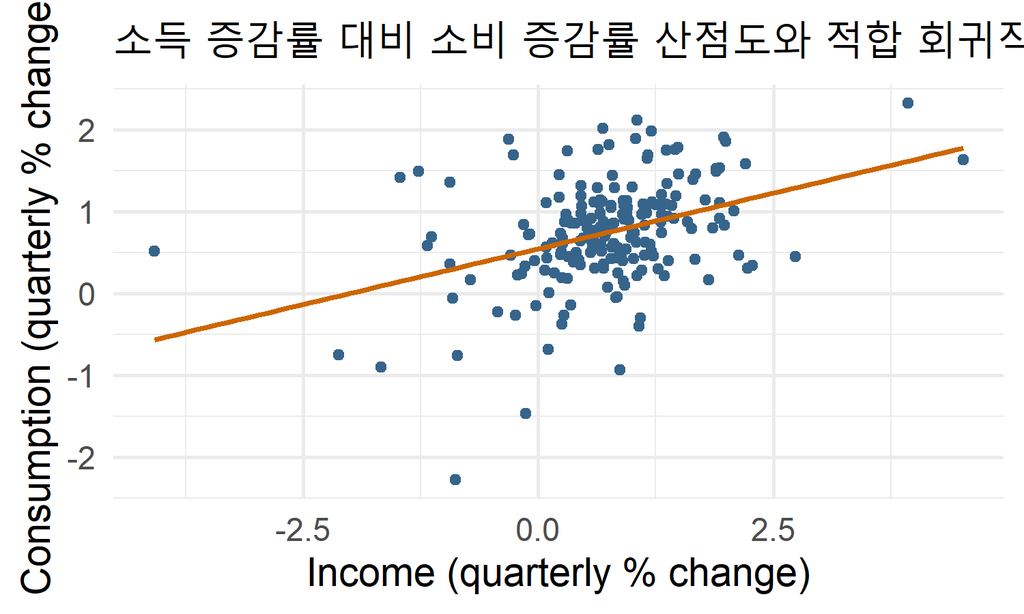

## 4. 회귀모형 적합

- 이제 **fable** 패키지를 이용하여 단순 선형회귀모형을 적합시킨다.

```r
fit_cons <- us_change |>
  model(lm = TSLM(Consumption ~ Income))
report(fit_cons)
```

```
## Series: Consumption
## Model: TSLM
##
## Residuals:
##      Min       1Q   Median       3Q      Max
## -2.58236 -0.27777  0.01862  0.32330  1.42229
##
## Coefficients:
##             Estimate Std. Error t value Pr(>|t|)
## (Intercept)  0.54454    0.05403  10.079  < 2e-16 ***
## Income       0.27183    0.04673   5.817  2.4e-08 ***
## ---
## Signif. codes:  0 '***' 0.001 '**' 0.01 '*' 0.05 '.' 0.1 ' ' 1
##
## Residual standard error: 0.5905 on 196 degrees of freedom
## Multiple R-squared: 0.1472,  Adjusted R-squared: 0.1429
## F-statistic: 33.84 on 1 and 196 DF, p-value: 2.4022e-08
```

## 5. 해석

적합된 직선의 **기울기(slope)** 가 양(+)이므로, **소득이 증가할수록 소비도 증가**하는 **정(+)의 관계**가 있음을 시사한다.

### 기울기의 의미

기울기 0.27의 해석:  
- \(x\)가 1 단위(가처분소득 증감률이 **1%p 증가**) 상승하면, \(y\)는 평균적으로 **0.27 단위(개인소비지출 증감률이 0.27%p 증가)** 상승한다.

## 5. 해석

### 추정식의 예시 계산

- 추정식은 다음과 같다.

\[ \hat{y}_t = 0.54 + 0.27x_t \]

- 여기에 \(x = 1\)을 대입하면,

\[ \hat{y} = 0.54 + 0.27 \times 1 = 0.82 \]

따라서 **소득이 1%p 증가할 때 소비는 평균적으로 0.82%p 증가**로 예측된다. (이 값에는 절편 효과가 포함되어 있다.)

## 5. 해석

### 절편(Intercept)의 해석과 필요성

- 절편 \(\beta_0\)의 해석은 **\(x = 0\)** 이 의미 있는 상황인지에 달려 있다.
  - 이 예에서는 \(x = 0\) (즉, 전분기 대비 가처분소득 변화가 없음)일 때, 예측되는 소비 증감률은 **0.54%** 이다.
- 설령 \(x = 0\)의 해석이 직관적이지 않더라도, 절편은 모형에서 **매우 중요한 역할**을 한다.
  - 절편을 제외하면 기울기 추정치가 불필요하게 왜곡될 수 있다.
- 특별히 **원점을 반드시 통과**하도록 강제할 필요가 없는 한,
  - 절편은 항상 포함하는 것이 일반적이다. 이하에서는 절편을 포함한다고 가정한다.

## 다중선형회귀 (Multiple Linear Regression)

## 다중선형회귀 개요

- 두 개 이상의 예측변수(predictor variables)가 포함될 때, 이러한 모형을 **다중회귀모형(multiple regression model)** 이라고 부른다.
  - 다중회귀모형의 일반적인 형태는 다음과 같다.

\[ y_t = \beta_0 + \beta_1 x_{1,t} + \beta_2 x_{2,t} + \cdots + \beta_k x_{k,t} + \varepsilon_t \]

여기서 \(y_t\)는 예측(forecast)하려는 변수이며, \(x_1, x_2, \dots, x_k\)는 \(k\)개의 예측변수들이다.

- 각 예측변수는 반드시 **수치형 변수(numerical variable)** 이어야 한다.
- 계수 \(\beta_1, \dots, \beta_k\)는 모형 내의 **다른 모든 변수들의 영향을 통제한 후**, 각 예측변수가 예측변수 \(y_t\)에 미치는 영향을 측정한다.
- 즉, 각 계수는 **해당 예측변수의 한계효과(marginal effect)** 를 나타낸다.

## 예시: 미국의 소비지출

다음 그림은 미국의 실질 개인소비지출을 예측할 때 추가적으로 고려할 수 있는 예측변수들을 보여준다.

- **산업생산(industrial production)** 의 분기별 증감률(%)
- **개인저축(personal savings)** 의 분기별 증감률(%)
- **실업률(unemployment rate)** 의 분기별 변화율(%) (이미 비율 형태이므로 차분값 사용)
- 이러한 변수들을 포함한 **다중선형회귀모형**을 구축하면, 개인소득만을 예측변수로 사용하는 단순회귀모형보다 **더 정확한 예측**을 얻을 가능성이 높다.
- 이는 개인소비지출이 개인소득뿐만 아니라, **생산, 저축, 고용상황 등 다양한 요인**에 의존하기 때문이다.

## 예시: 미국의 소비지출

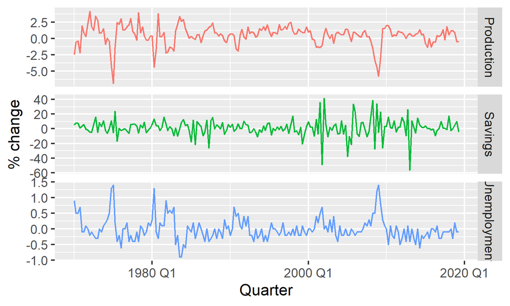

## 변수 간 관계

다음 그림은 다섯 개 변수 간의 관계를 보여주는 **산점도 행렬(scatterplot matrix)** 이다.  
- 첫 번째 열은 예측변수(소비지출)와 각 예측변수 간의 관계를 나타낸다.  
산점도에 따르면,

- **소득(Income)** 과 **산업생산(Production)** 은 **소비(Consumption)** 와 **양(+)의 관계**를 보이며,
- **저축(Savings)** 과 **실업(Unemployment)** 은 **음(-)의 관계**를 보인다.
- 이러한 관계의 강도는 첫 번째 행에 제시된 **상관계수(correlation coefficients)** 로 확인할 수 있다.
  - 나머지 산점도와 상관계수들은 예측변수들 간의 상호 관계를 보여준다.

## 변수 간 관계

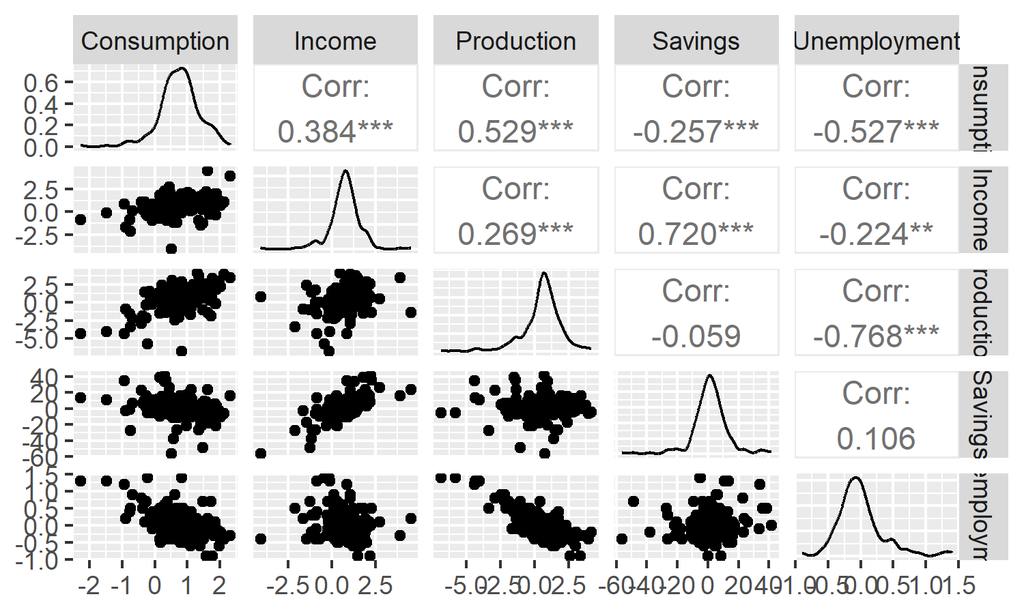

## 선형모형의 가정

## 선형모형의 가정

선형회귀모형(linear regression model)을 사용할 때, 다중회귀모형의 식에 포함된 변수들에 대해 몇 가지 **암묵적인 가정(assumptions)** 을 두게 된다.

## 1. 모형의 적합성(Linear relationship)

- 우선, 이 모형이 현실에 대한 **합리적인 근사(approximation)** 라는 가정을 한다.
- 즉, 예측변수와 설명변수들 간의 관계가 **선형식(linear equation)** 형태로 표현될 수 있다고 본다.

\[ y_t = \beta_0 + \beta_1 x_{1,t} + \beta_2 x_{2,t} + \cdots + \beta_k x_{k,t} + \varepsilon_t \]

## 2. 오차항(Errors, \(\varepsilon_1, \ldots, \varepsilon_T\))에 대한 가정

- 오차항에 대해서는 다음과 같은 통계적 가정을 둔다.
1. **기대값이 0이다 (E[\(\varepsilon_t\)] = 0).**  
   → 그렇지 않다면, 예측값이 체계적으로 편향(bias)될 것이다.
2. **자기상관이 없다 (no autocorrelation).**  
   → 오차항들이 서로 상관되어 있다면, 데이터 내의 추가 정보를 활용하지 못하게 되어 예측이 비효율적(inefficient)일 수 있다.
3. **예측변수들과 상관되지 않는다 (no correlation with predictors).**  
   → 오차항이 설명변수들과 관련되어 있다면, 그 정보는 모형의 체계적 부분(systematic part)에 포함되어야 한다는 뜻이다.

또한, 예측구간(prediction interval)을 쉽게 산출하기 위해 오차항이 **정규분포** 를 따르고  
**분산이 일정(constant variance, \(\sigma^2\))** 하다고 가정하는 것이 유용하다.

## 3. 예측변수의 비확률성

- 선형회귀모형에서 또 하나의 중요한 가정은  
  각 예측변수 \(x\)가 **확률변수가 아니라는 것(non-random)** 이다.
  - 실험실에서 **통제된 실험(controlled experiment)** 을 수행한다면, 각 \(x\)의 값을 우리가 직접 설정하고, 그에 따른 \(y\)의 변화를 관찰할 수 있을 것이다.
  - 이 경우 \(x\)는 임의(random)가 아니라 고정(fixed)된 값이다.
- 그러나 실제로 우리가 다루는 **관찰자료(observational data)** — 특히 **경제·경영 데이터** —에서는 \(x\)의 값을 통제할 수 없으며, 단지 **관측(observe)** 할 뿐이다.
- 따라서 우리는 이러한 비확률성(non-randomness)을 **모형의 기본 가정**으로 둔다.

## 최소제곱추정 (Least Squares Estimation)

## 최소제곱추정

- 실제 분석에서는 여러 관측값(observations)을 가지고 있지만, 계수 \(\beta_0, \beta_1, \ldots, \beta_k\)의 참값(true values)은 알 수 없다.
  - 따라서 이 계수들은 데이터를 이용해 **추정(estimation)** 해야 한다.

## 1. 최소제곱원리 (Least Squares Principle)

**최소제곱원리(least squares principle)** 는 오차 제곱의 합(sum of squared errors, SSE)을 최소화함으로써 계수를 효과적으로 선택하는 방법을 제시한다.

- 즉, 다음 식을 최소화하는 \(\beta_0, \beta_1, \ldots, \beta_k\) 값을 선택한다.

\[ \sum_{t=1}^{T} \varepsilon_t^2 = \sum_{t=1}^{T} (y_t - \beta_0 - \beta_1 x_{1,t} - \beta_2 x_{2,t} - \cdots - \beta_k x_{k,t})^2 \]

- 이 방법을 **최소제곱추정(least squares estimation)** 이라고 부르는 이유는, 위 식이 오차 제곱의 합을 가장 작게 하는(least squares) 값을 찾아내기 때문이다.

## 2. 모형의 적합(Fitting the Model)

- 이렇게 추정된 계수는 데이터를 가장 잘 설명하는 모형으로 간주되며, 이를 **모형을 적합(fitting)** 한다고 한다.  
  또는 **모형을 학습(learning)** 하거나 **훈련(training)** 시킨다고도 표현한다.
- 앞선 산점도 그림에서 제시된 회귀선(regression line)도 바로 이러한 방식으로 얻어진 것이다.

## 3. 추정된 계수의 표기법 (Estimated Coefficients)

- 추정된 계수는 모자(hat, ^) 기호를 붙여 \(\hat{\beta}_0, \hat{\beta}_1, \ldots, \hat{\beta}_k\)로 표기한다.
- 이들에 대한 구체적인 식은 이 장의 마지막에서 다룬다.

## 4. TSLM() 함수의 역할

- `TSLM()` 함수는 시계열 자료(time series data)에  
  **선형회귀모형(linear regression model)** 을 적합하는 기능을 제공한다.
- 이는 일반적으로 선형모형에 사용되는 `lm()` 함수와 유사하지만, 시계열 분석에 특화된 추가 기능들을 포함하고 있다.

## 예시: 미국의 소비지출 (US Consumption Expenditure)

미국의 소비지출을 설명하기 위한 **다중선형회귀모형** 은 다음과 같다.

\[ y_t = \beta_0 + \beta_1 x_{1,t} + \beta_2 x_{2,t} + \beta_3 x_{3,t} + \beta_4 x_{4,t} + \varepsilon_t \]

여기서 각 변수의 의미는 다음과 같다.

- \(y_t\): 실질 개인소비지출의 **분기별 증감률(%)**
- \(x_{1,t}\): 실질 개인 가처분소득의 **분기별 증감률(%)**
- \(x_{2,t}\): 산업생산의 **분기별 증감률(%)**
- \(x_{3,t}\): 개인저축의 **분기별 증감률(%)**
- \(x_{4,t}\): 실업률의 **분기별 변화율(%)**
- \(\varepsilon_t\): 오차항

## 회귀모형의 추정결과 (Model Output)

- `Coefficients`의 첫 번째 열은 각 \(\beta\) 계수의 추정값(estimate)을, 두 번째 열은 해당 추정값의 **표준오차(standard error)** 를 나타낸다.
- 표준오차는 동일한 데이터 생성 과정을 반복하여 여러 번 추정했을 때, \(\beta\) 계수의 추정치가 갖는 **표준편차(standard deviation)** 에 해당한다.

```
## Series: Consumption
## Model: TSLM
##
## Residuals:
##      Min       1Q   Median       3Q      Max
## -0.90555 -0.15821 -0.03608  0.13618  1.15471
##
## Coefficients:
##               Estimate Std. Error t value Pr(>|t|)
## (Intercept)   0.253105   0.034470   7.343 5.71e-12 ***
## Income        0.740583   0.040115  18.461  < 2e-16 ***
## Production    0.047173   0.023142   2.038   0.0429 *
## Unemployment -0.174685   0.095511  -1.829   0.0689 .
## Savings      -0.052890   0.002924 -18.088  < 2e-16 ***
## ---
## Signif. codes:  0 '***' 0.001 '**' 0.01 '*' 0.05 '.' 0.1 ' ' 1
##
## Residual standard error: 0.3102 on 193 degrees of freedom
## Multiple R-squared: 0.7683,  Adjusted R-squared: 0.7635
## F-statistic:   160 on 4 and 193 DF, p-value: < 2.22e-16
```

## 통계적 유의성에 관한 열(Column)들

예측(forecasting)을 목적으로 할 때는, 출력의 마지막 두 열인 **“t value”** 와 **“p-value”** 는 상대적으로 중요성이 낮다.

- **t value**는 각 \(\beta\) 계수의 추정값을 그 표준오차로 나눈 비율로,  
  계수가 0과 통계적으로 유의하게 다른지를 검정하는 데 사용된다.
- **p-value**는 해당 예측변수와 소비지출 간에 실제 관계가 없다고 가정했을 때,  
  관찰된 t값만큼 큰(또는 더 큰) 값이 나올 확률을 의미한다.

이 두 값은 각 예측변수가 **통계적으로 유의미한지(significant)** 를 평가할 때는 유용하지만, **예측의 정확도 향상** 을 판단할 때는 상대적으로 덜 중요하다.

## 모형의 적합도

## 적합값 (Fitted Values)

- 회귀식에서 추정된 계수들을 이용하고, 오차항을 0으로 설정하면\(y\)의 예측값(predictions)을 구할 수 있다.

\[ \hat{y}_t = \hat{\beta}_0 + \hat{\beta}_1 x_{1,t} + \hat{\beta}_2 x_{2,t} + \cdots + \hat{\beta}_k x_{k,t} \]

여기서 \(t = 1, \ldots, T\)에 대해 \(x_{1,t}, \ldots, x_{k,t}\)의 실제 값을 대입하면, 훈련 데이터(training set) 내에서의 \(y_t\) 예측값을 얻을 수 있다.  
- 이러한 예측값을 **적합값(fitted values)** 이라고 한다. - 주의할 점은, 적합값은 모형 추정을 위해 사용된 기존 데이터에 대한 예측값이지, **미래 시점의 진짜 예측(forecasts)** 은 아니라는 것이다.

## 미국 소비지출의 적합값 예시

- 아래의 그림들은 미국 개인소비지출(US consumption expenditure) 증감률(%) 자료에서 실제값(actual values)과 적합값(fitted values)을 비교한 것이다.
- 시계열 그래프는 적합값이 실제 데이터의 흐름을 비교적 잘 따라가는 모습을 보여준다.
- 산점도(에서도 두 변수 간에 강한 **양(+)의 관계** 가 나타나, 모형의 적합도가 높음을 확인할 수 있다.

## 미국 소비지출의 적합값 예시

**미국 개인소비지출 증감률의 실제값과 적합값 비교 (시계열 그래프)**

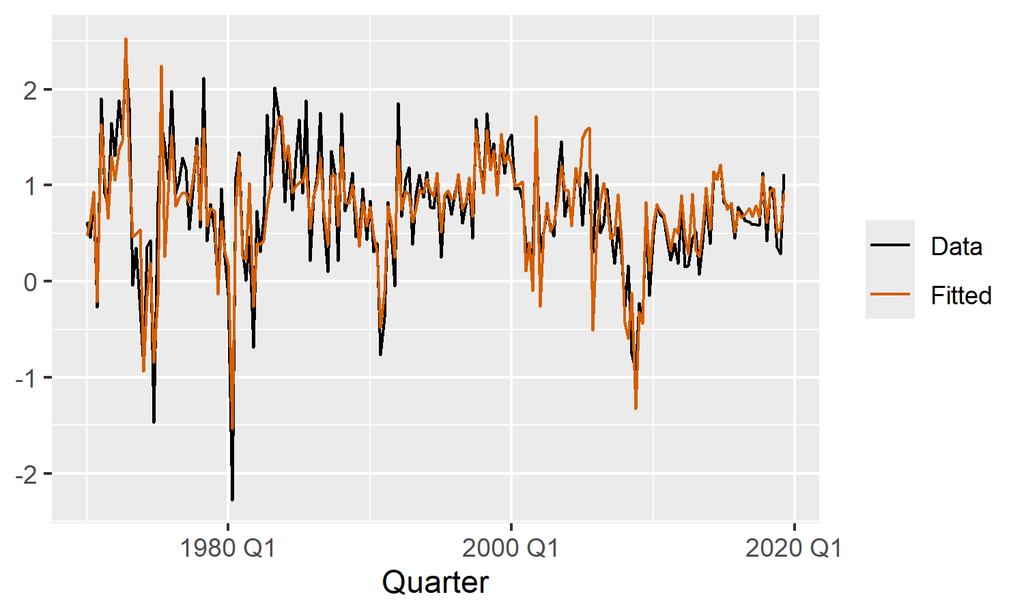

## 미국 소비지출의 적합값 예시

**미국 개인소비지출 증감률의 실제값과 적합값 비교 (산점도)**

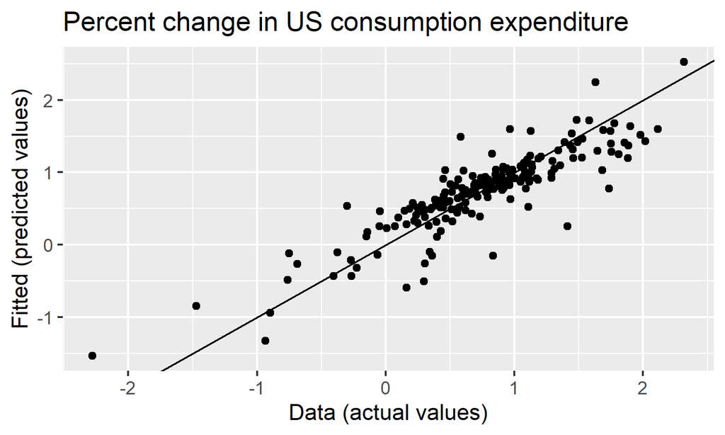

## 적합도의 척도 (Goodness-of-Fit)

선형회귀모형이 데이터를 얼마나 잘 설명하는지를 요약하는 대표적인 방법은 **결정계수(coefficient of determination)**, 즉 **\(R^2\)** 값을 이용하는 것이다.

## 1. 결정계수의 정의

- \(R^2\)는 관측된 \(y\) 값과 예측된 \(\hat{y}\) 값 간의 **상관계수(correlation coefficient)** 의 제곱으로 계산할 수 있다.

\[ R^2 = \frac{ \sum (\hat{y}_t - \bar{y})^2 }{ \sum (y_t - \bar{y})^2 } \]

이 식에서 모든 합은 전체 관측값을 기준으로 계산된다.  
- 즉, \(R^2\)은 **회귀모형이 예측변수** 의 변동 중 얼마나 많은 부분을 설명하는지를 나타낸다.

## 2. 단순회귀(Simple Regression)의 경우

단순선형회귀모형에서(절편 포함 시), \(R^2\) 값은 \(y\)와 \(x\) 간의 상관계수의 제곱과 동일하다.

즉, \[ R^2 = (\text{Cor}(y, x))^2 \]

## 3. \(R^2\)의 해석

- 예측값이 실제값에 매우 근접하면 \(R^2 \approx 1\) 이 된다.
- 예측값이 실제값과 전혀 관련이 없으면 \(R^2 = 0\) 이 된다.  
  (단, 절편이 포함되어 있다고 가정할 때)

모든 경우에서 \(R^2\) 값은 항상 **0과 1 사이**에 존재한다.

## 4. \(R^2\) 사용 시 주의사항

\(R^2\)는 널리 사용되지만, 종종 **잘못 해석되는 지표**이기도 하다.

- 새로운 예측변수를 추가하면 \(R^2\)는 **절대 감소하지 않는다.**  
  → 이는 모형의 **과적합(over-fitting)** 을 초래할 수 있다.
- 좋은 \(R^2\)의 기준값은 **자료의 성격**에 따라 다르다.
- 따라서 \(R^2\)을 훈련데이터(training data)에 대해 계산하기보다는,  
  **검증데이터(test data)** 에서 예측 성능을 평가하는 것이 훨씬 더 바람직하다.

## 예시: 미국의 소비지출

실제 소비지출과 적합값(fitted values)의 산점도에서, 이 두 변수 간의 상관계수는  
\[ r = 0.877 \] 따라서, \[ R^2 = 0.877^2 = 0.768 \]

즉, 이 모형은 소비지출 데이터의 **76.8%의 변동성(variation)** 을 설명하고 있다.  
- 이는 앞서 단순회귀모형으로 얻었던 \(R^2 = 0.15\)보다 훨씬 높은 수치이다.  
- 세 개의 예측변수를 추가함으로써, 모형이 데이터의 변동을 훨씬 더 잘 설명하게 된 것이다.

## 회귀의 표준오차

- 모형의 적합도를 평가하는 또 다른 척도는 **잔차** 의 표준편차로, 이를 흔히 **잔차표준오차** 라고 부른다.
  - 앞선 출력 결과에서는 이 값이 **0.31**로 나타났다.

\[ \hat{\sigma}_e = \sqrt{ \frac{1}{T - k - 1} \sum_{t=1}^{T} e_t^2 } \]

여기서,

- \(T\): 전체 관측값의 수
- \(k\): 예측변수의 수
- \(e_t\): 잔차(residual)
- 분모에 \(T - k - 1\)이 사용되는 이유는, 우리가 \(k + 1\)개의 모수(절편 1개와 각 예측변수의 계수 \(k\)개)를 추정했기 때문이다.

## 1. 표준오차의 의미

- 회귀의 표준오차는 모형이 평균적으로 어느 정도의 오차를 내는지를 보여준다.
- 이 값을 \(y\)의 표본평균(sample mean)이나 표본표준편차(sample standard deviation)와 비교하면, 모형의 **예측정확도(accuracy)** 를 직관적으로 파악할 수 있다.

## 2. 예측구간에서의 활용

회귀의 표준오차는 **예측구간(prediction interval)** 을 계산할 때 중요한 역할을 하며, 이에 대한 자세한 내용은 추후에 다룬다.

## 회귀모형의 평가

## 잔차의 정의 (Definition of Residuals)

- 관측된 \(y\) 값과 이에 대응하는 적합값 \(\hat{y}\) 의 차이를 **훈련자료 오차(training-set errors)** 또는 **잔차(residuals)** 라고 하며, 다음과 같이 정의된다.

\[ e_t = y_t - \hat{y}_t = y_t - \hat{\beta}_0 - \hat{\beta}_1 x_{1,t} - \hat{\beta}_2 x_{2,t} - \cdots - \hat{\beta}_k x_{k,t}, \quad t = 1, \ldots, T \]

- 각 잔차 \(e_t\)는 해당 관측값에서 **예측할 수 없는(unpredictable)** 부분을 나타낸다.

## 잔차의 주요 성질 (Properties of Residuals)

- 잔차는 다음과 같은 중요한 수학적 성질들을 가진다.

\[ \sum_{t=1}^{T} e_t = 0 \quad \text{and} \quad \sum_{t=1}^{T} x_{k,t} e_t = 0 \quad \text{for all } k. \]

이로부터 다음 사실을 알 수 있다.

- 잔차의 평균은 항상 **0**이다.
- 잔차와 각 예측변수의 관측값 간의 **상관관계(correlation)** 도 0이다.

(단, 이는 모형에 절편(intercept)이 포함된 경우에만 성립하며,  
절편이 없는 모형에서는 반드시 성립하지 않는다.)

## 잔차 분석의 필요성 (Residual Diagnostics)

- 회귀변수를 선택하고 모형을 적합(fit)한 후에는, **잔차를 시각화하여(model diagnostics)** 모형의 가정들이 잘 충족되는지를 반드시 확인해야 한다.
- 이를 위해 다양한 형태의 잔차그래프(residual plots)를 작성하며, 각각의 그래프는 적합된 모형(fitted model)과 그 기저 가정(underlying assumptions)의 서로 다른 측면을 점검하는 역할을 한다.

## 잔차의 ACF와 히스토그램 (ACF and Histogram of Residuals)

## 1. 잔차의 자기상관함수(ACF) 확인

- 시계열 데이터의 경우, 현재 시점의 관측값은 직전 시점(혹은 그 이전 시점)의 값과 **유사한 경향** 을 보일 가능성이 높다.
- 따라서 회귀모형을 시계열 자료에 적합할 때, **잔차** 에서 **자기상관(autocorrelation)** 이 나타나는 것은 흔한 일이다.
- 이런 경우, 추정된 모형은 “오차항 간 독립성” 가정을 위반하게 되며, 예측치는 여전히 **불편(unbiased)** 하지만 **비효율적(inefficient)** 이 된다.
  - 즉, 모형이 활용하지 못한 추가 정보가 남아 있어 이를 반영하면 더 나은 예측력을 얻을 수 있다.
- 자기상관이 존재하는 모형의 예측치는 **편향되지 않지만**, 불필요하게 **넓은 예측구간** 을 가지게 된다.
  - 따라서 항상 **잔차의 ACF 플롯(autocorrelation function plot)** 을 확인해야 한다.

## 2. 잔차의 히스토그램 (Histogram of Residuals)

- 잔차가 **정규분포(normal distribution)** 를 따르는지 점검하는 것은 매우 유용하다.
- 앞서 설명했듯이 정규성 가정은 예측 자체에 필수적이지는 않지만, **예측구간** 을 계산할 때 훨씬 간편하게 만들어 준다.

## 3. 예시 (Example)

`gg_tsresiduals()` 함수를 사용하면 앞서 언급한 여러 잔차 진단을 한 번에 시각화할 수 있다.

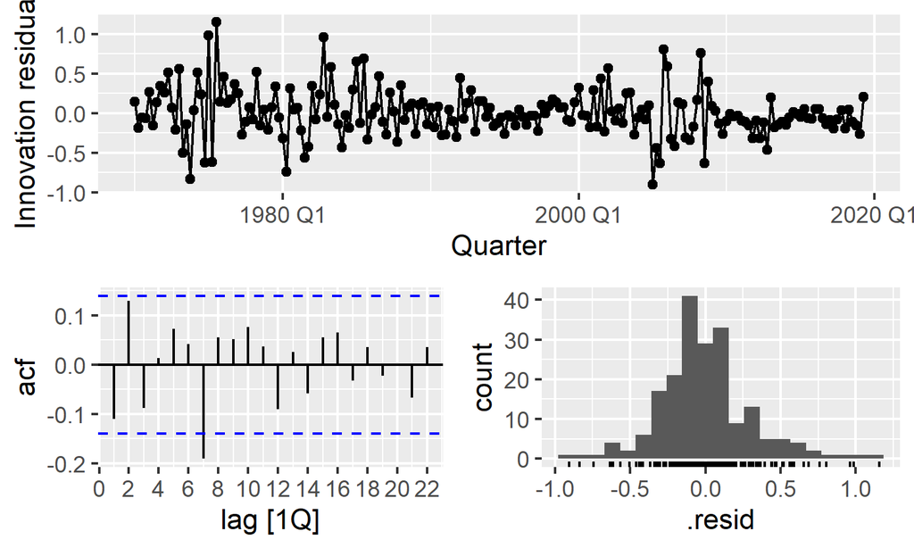

## 3. 예시 (Example)

```r
augment(fit_consMR) |>
  features(.innov, ljung_box, lag = 10)
```

```
## # A tibble: 1 × 3
##   .model lb_stat lb_pvalue
##   <chr>    <dbl>     <dbl>
## 1 tslm      18.9    0.0420
```

## 4. 시각화 종류별 특성

- **시계열 그래프)**:  
  잔차의 분산이 시간에 따라 다소 변하는 모습이 관찰된다.  
  이러한 **이분산성(heteroscedasticity)** 은 예측구간의 신뢰수준(coverage) 정확도에 영향을 미칠 수 있다.
- **히스토그램(histogram)**:  
  잔차 분포가 약간의 **비대칭(skewness)** 을 보이며, 이 역시 예측구간의 신뢰수준에 영향을 줄 가능성이 있다.
- **자기상관함수(ACF) 플롯**:  
  시차 7(lag 7)에서 유의한(spike) 자기상관이 나타났으며,  
  5% 유의수준에서 **Ljung–Box 검정(Ljung–Box test)** 도 유의하게 나왔다.  
  그러나 자기상관의 크기가 매우 크지 않으며, 시차 7에서 발생한 정도로는 예측치나 예측구간에 뚜렷한 영향을 미치지는 않을 것으로 보인다.

## 5. 잔차의 정보 활용

- 잔차에 남아 있는 정보를 보다 잘 포착하기 위해,  
  추후 **동적회귀모형(dynamic regression models)** 을 다룰 예정이다.
- 이러한 모형은 오차항의 구조적 패턴을 반영함으로써  
  더 나은 예측을 가능하게 한다.

## 예측변수에 대한 잔차도

## 예측변수에 대한 잔차도

-회귀모형이 잘 적합되었다면, **잔차(residuals)** 는 일정한 패턴 없이 무작위로(randomly) 흩어져 있어야 한다.

- 이를 빠르고 간단하게 확인하는 방법은 **각 예측변수(predictor variable)** 에 대해 잔차를 y축, 예측변수를 x축으로 한 **산점도(scatterplot)** 를 그려보는 것이다.

## 1. 잔차와 예측변수 간의 관계 점검

- 잔차–예측변수 산점도에서 특정한 **패턴(pattern)** 이 나타난다면, 이는 두 변수 간의 관계가 **비선형적(nonlinear)** 일 가능성을 시사한다.
- 이 경우, 현재의 선형회귀모형(linear regression model)은 적절하지 않으며 모형을 **수정(modify)** 하거나 **비선형 회귀모형(nonlinear regression model)** 으로 확장할 필요가 있다.

비선형 회귀모형에 대한 자세한 논의는 추후에 한다.

## 2. 모형에 포함되지 않은 변수에 대한 점검

- 또한, 모형에 포함되지 않은 예측변수들에 대해서도 잔차와의 관계를 시각화하는 것이 중요하다.
- 만약 이러한 변수들과의 잔차 산점도에서 일정한 패턴이 관찰된다면, 그 변수는 (비선형 형태를 포함하여) **모형에 추가** 해야 할 필요가 있다.

## 3. 예시

- 미국의 소비지출을 예측하기 위한 다중회귀모형에서 얻은 잔차를 각 예측변수에 대해 산점도로 나타낸 그림을 보면, 잔차들이 비교적 무작위로 흩어져(randomly scattered) 있는 것을 확인할 수 있다.

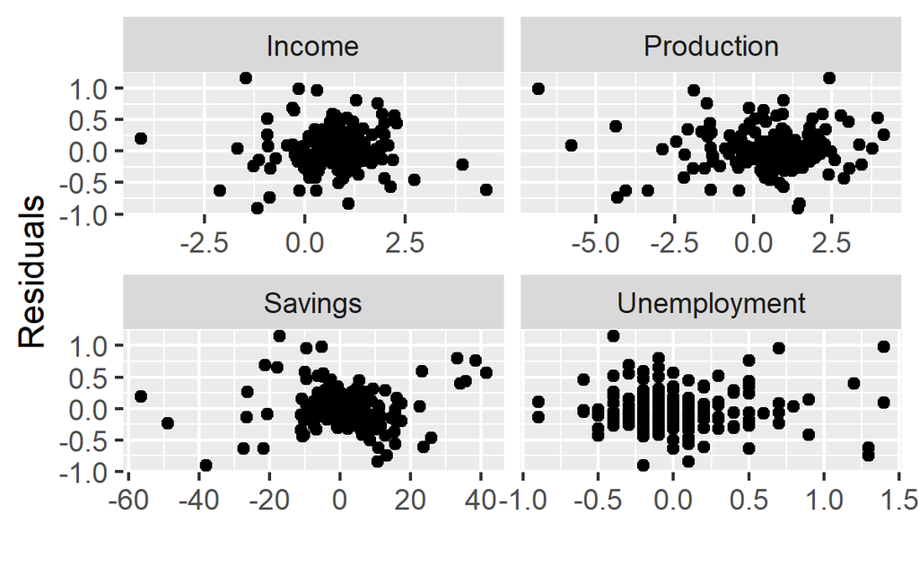

## 잔차 대 적합값 그래프

## 1. 잔차와 적합값의 관계

- 잔차(residuals)를 적합값(fitted values)에 대해 그래프로 나타냈을 때, **어떠한 패턴(pattern)** 도 나타나지 않아야 한다.
- 만약 특정한 패턴이 관찰된다면, 이는 오차항의 분산이 일정하지 않다는 의미로 **이분산성(heteroscedasticity)** 이 존재함을 시사한다.
  - 즉, 잔차의 분산이 일정하지 않고(비정상적 변화), 예측변수의 값에 따라 커지거나 작아질 수 있다.
- 이 문제가 발생할 경우, 예측변수나 예측대상 변수를 **변환(transformation)** 해야 할 필요가 있다.
  - 예를 들어, 로그 변환(logarithm)이나 제곱근 변환(square root transformation)과 같은 방법이 유용할 수 있다.

## 2. 예시

- 무작위로 흩어진 형태를 보이므로, 오차항이 **등분산성(homoscedasticity)** 을 가진다고 판단할 수 있다.

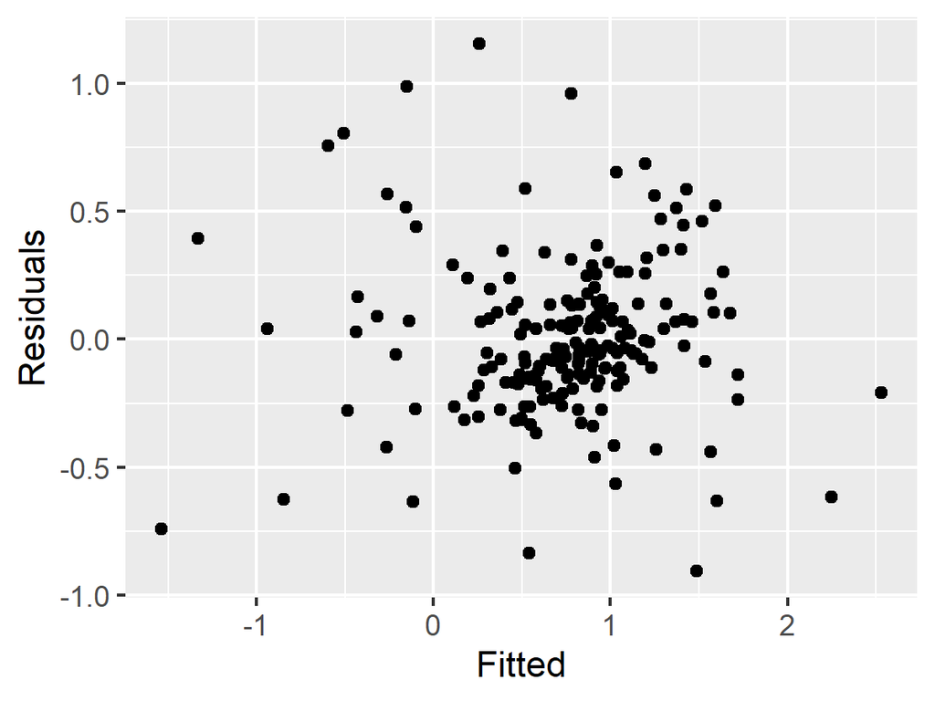

## 이상치와 영향력 관측값 (Outliers and Influential Observations)

## 1. 개념 정의

- **이상치(Outliers)**:  
  전체 데이터의 대부분과 비교했을 때 **극단적인 값을 가지는 관측치**를 말한다.
- **영향력 관측값**: 회귀모형의 **추정된 계수** 에 큰 영향을 미치는 관측값을 의미한다.
- 일반적으로, 영향력 있는 관측값은 예측변수 \(x\) 방향에서 극단적인 값을 가지는 **이상치(outlier)** 인 경우가 많다.

## 2. 이상치 탐지의 중요성

- 이상치와 영향력 관측값을 탐지하는 **공식적 통계기법(formal statistical methods)** 이 존재하지만, 이는 본 교재의 범위를 벗어난다.
- 그러나, 서두에서 언급했듯이, 데이터 분석에 앞서 **자료를 충분히 이해하는 것** 이  
  매우 중요하다.
- 각 \(x\) 변수에 대해 \(y\)와의 **산점도(scatter plot)** 를 작성하는 것은 회귀분석의 기본적 출발점이자, 비정상적 관측값(unusual observations)을 파악하는 데 매우 유용하다.

## 3. 이상치의 원인과 처리 방법

### (1) 데이터 입력 오류

- 이상치의 한 원인은 잘못된 데이터 입력이다.
- 데이터의 **기초 기술통계(descriptive statistics)** 를 검토하면 비상식적인 최소값(minima)이나 최대값(maxima)을 쉽게 식별할 수 있다.
- 잘못 기록된 값이 확인되면, 즉시 수정하거나 해당 관측치를 **표본에서 제거(remove)** 해야 한다.

## 3. 이상치의 원인과 처리 방법

### (2) 본질적 차이를 가진 관측값

- 이상치는 단순히 다른 특성을 가진 관측값일 수도 있다. 이 경우, 무조건 제거하는 것은 바람직하지 않다.
- 이상치로 의심되는 관측값이 있다면, 그 발생 원인을 충분히 분석하고 이해해야 한다.
  - 특히 해당 이상치가 **영향력 관측값** 인 경우, 제거 여부를 결정하는 것은 매우 신중해야 한다.
- 가장 좋은 접근법은 **이상치를 포함했을 때와 제외했을 때의 결과를 모두 보고하는 것**이다.

## 4. 예시

다음 그림은 미국 소비지출을 소득에 대해 회귀분석할 때, 단 하나의 이상치가 회귀결과에 미치는 영향을 보여준다

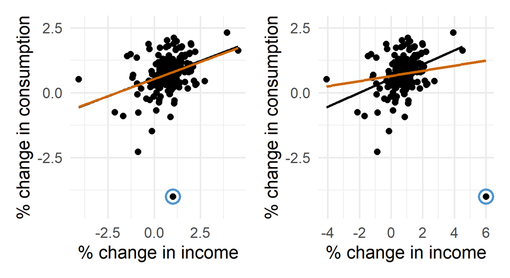

## 가성회귀 (Spurious Regression)

## 1. 비정상 시계열과 회귀모형의 문제

- 시계열 자료(time series data)는 대부분의 경우 **비정상(non-stationary)** 적 특성을 가진다.
  - 즉, 시계열의 값이 일정한 평균(상수 평균)을 중심으로 변동하지 않거나, 분산이 일정하지 않은 경우를 의미한다.
- 시계열의 정상성(stationarity)에 대해서는 이미 다루었지만 여기서는 비정상 자료가 회귀모형에 미치는 영향을 살펴본다.

## 2. 예시

다음 그림에 제시된 두 시계열 변수를 생각해보자.

- 두 변수는 모두 **상승 추세(trend)** 를 가지며 비슷한 형태로 증가하기 때문에, 표면적으로는 서로 관련이 있어 보인다.
- 그러나 실제로 **호주 항공여객 수** 와 **기니의 쌀 생산량(rice production in Guinea)** 은 아무런 경제적 관련이 없다.
- 단지 두 시계열이 공통적으로 상승하는 추세를 가지기 때문에 서로 관계가 있는 것처럼 **잘못된 인과관계** 가 나타나는 것이다.

## 2. 예시

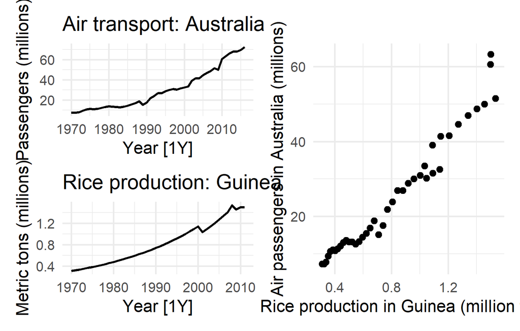

## 4. 예측에서의 문제점

- 가성회귀 모형은 **단기적으로는 그럴듯한 예측** 을 제공할 수도 있다.
- 그러나 이러한 모형은 **장기적으로 예측력이 유지되지 않으며**,시간이 지남에 따라 예측 성능이 급격히 저하된다.
- 즉, 비정상 시계열 간의 단순 회귀는 통계적으로 신뢰할 수 없는 결과를 초래할 가능성이 높으므로 항상 **정상성 검정** 을 수행하고, 필요한 경우 **차분** 등의 적절한 전처리를 수행해야 한다.

## 유용한 예측변수들

## 1. 추세

시계열 데이터는 종종 **추세** 를 보인다.  
- 이러한 추세는 시간의 흐름에 따라 데이터가 일정한 방향으로 증가하거나 감소하는 경향을 의미한다.

- 가장 단순한 형태의 **선형추세** 는 시간 \(t\) 자체를 예측변수로 사용하는 방식으로 모델링할 수 있다.

\[ y_t = \beta_0 + \beta_1 t + \varepsilon_t, \quad t = 1, \ldots, T \]

- 즉, 시간 변수를 그대로 \(x_{1,t} = t\) 로 두면 된다.
  - 여기서 \(\beta_1\)은 **시간이 한 단위 증가할 때의 평균적인 변화율(slope)** 을 의미하며, \(\beta_0\)은 시계열의 시작점 수준(intercept level)을 나타낸다.

## 2. TSLM() 함수에서의 추세변수 지정

- `TSLM()` 함수에서는 `trend()` 특수함수를 사용하여 추세변수를 쉽게 추가할 수 있다.
  - 한편, 추세가 반드시 선형일 필요는 없다.
- 다른 절에서 추세가 비선형적 일 때 이를 모델링하는 방법들(예: 다항식 추세, 로그 변환, 지수 추세 등)에 대해 자세히 다룰 것이다.

## 더미변수

## 1. 개념

- 지금까지는 각 예측변수(predictor)가 **수치형 변수(numerical variable)** 라고 가정했다.
- 그러나 예측변수가 **범주형 변수(categorical variable)** 인 경우도 있다.
  - 예를 들어, 일일 매출을 예측할 때 그 날이 **공휴일** 인지 아닌지를 고려하고자 한다면, - 예측변수는 두 가지 값, 즉 `"yes"` 또는 `"no"`를 취하게 된다.
- 이러한 경우에도 다중회귀모형 내에서 “**더미변수**” 또는 “**지시변수**”를 사용함으로써 문제를 처리할 수 있다.

## 2. 더미변수의 정의와 사용

- 더미변수는 특정 조건이 충족될 때 **1**, 그렇지 않으면 **0**을 부여하는 변수이다.
- 예를 들어,
  - 공휴일이면 \(D_t = 1\),
  - 평일이면 \(D_t = 0\) 으로 정의할 수 있다.
- 이렇게 하면 회귀모형에 범주형 요인을 포함시킬 수 있으며, 각 더미변수의 계수는 해당 조건이 있을 때 예측변수의 평균 변화 효과를 추정하게 된다.

## 3. 이상치를 설명하기 위한 더미변수

- 더미변수는 **이상치나 특별한 사건** 의 영향을 분리하기 위해서도 사용할 수 있다.
  - 이 경우, 이상치가 발생한 시점의 관측치에 대해서만 더미변수를 1로 설정하고, 나머지는 모두 0으로 둔다.
- 예를 들어, 2016년 **리우데자네이루 올림픽** 이 브라질의 관광객 유입에 영향을 미쳤다면, 2016년 기간의 더미변수를 추가하여 그 효과를 반영할 수 있다.

## 4. 두 개 이상의 범주를 가지는 경우

- 만약 범주가 두 개보다 많다면, 총 범주 수보다 **하나 적은 개수의 더미변수**로 코딩한다.
  - 예를 들어, 범주가 7개라면 6개의 더미변수를 사용한다.
- `TSLM()` 함수는 **factor 변수**를 예측변수로 지정할 경우 자동으로 필요한 더미변수를 생성하므로, 일반적으로 수동으로 더미변수를 만들 필요가 없다.

## 5. 계절 더미변수

- 예를 들어, 일일 데이터를 예측할 때 **요일** 을 예측변수로 고려하고자 한다면 아래와 같이 요일별 더미변수를 설정할 수 있다.

## 5. 계절 더미변수

| Day | \(d_{1,t}\) | \(d_{2,t}\) | \(d_{3,t}\) | \(d_{4,t}\) | \(d_{5,t}\) | \(d_{6,t}\) |
| --- | --- | --- | --- | --- | --- | --- |
| Monday | 1 | 0 | 0 | 0 | 0 | 0 |
| Tuesday | 0 | 1 | 0 | 0 | 0 | 0 |
| Wednesday | 0 | 0 | 1 | 0 | 0 | 0 |
| Thursday | 0 | 0 | 0 | 1 | 0 | 0 |
| Friday | 0 | 0 | 0 | 0 | 1 | 0 |
| Saturday | 0 | 0 | 0 | 0 | 0 | 1 |
| Sunday | 0 | 0 | 0 | 0 | 0 | 0 |

## 6. “더미변수 함정”

- 요일이 7개임에도 불구하고 더미변수가 6개만 필요한 이유는,  
  마지막 요일(이 경우 Sunday)은 **절편** 항이 대신 설명하기 때문이다.
- 모든 더미변수가 0일 때 해당되는 범주(즉, Sunday)가  
  **기준 범주** 로 설정된다.
- 자주 발생하는 실수는 7개의 요일 모두에 대해 더미변수를 추가하는 것이다.
  - 이를 “**더미변수 함정**”이라고 하며, 절편이 이미 포함되어 있는 모형에서는 **모수의 중복(multicollinearity)** 으로 인해 회귀모형이 계산되지 않는다.

## 6. “더미변수 함정”

- 일반적인 규칙은 다음과 같다.

| 데이터 주기 | 범주 수 | 필요한 더미변수 수 |
| --- | --- | --- |
| 분기별(Quarterly) | 4 | 3 |
| 월별(Monthly) | 12 | 11 |
| 일별(Daily) | 7 | 6 |

## 7. 더미변수 계수의 해석

- 각 더미변수에 대응하는 계수는 **생략된 기준 범주** 대비 해당 범주의 효과를 의미한다.
  - 예를 들어, 위 표에서 월요일에 해당하는 더미변수 \(d_{1,t}\)의 계수는 **월요일이 일요일에 비해 예측변수에 미치는 평균적 영향 차이**를 나타낸다.

## 호주의 맥주 생산량

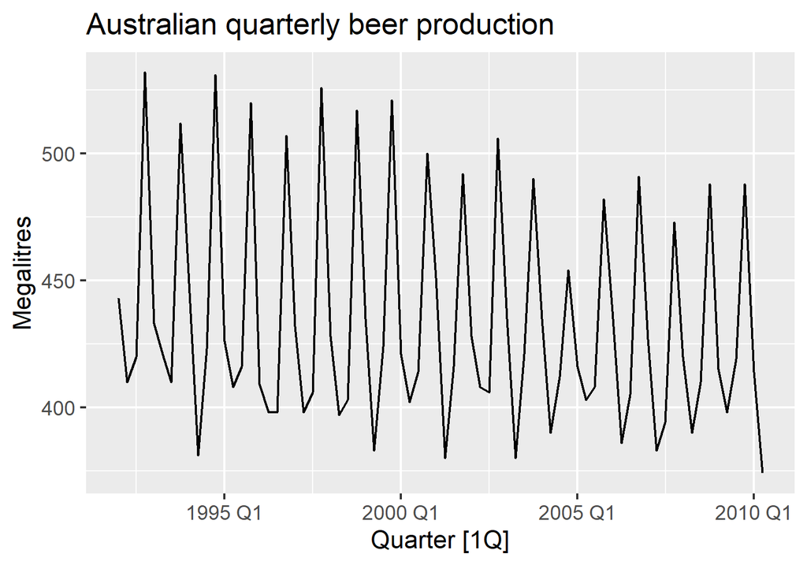

## 호주의 맥주 생산량: 1. 회귀모형 설정

- 우리는 향후 맥주 생산량을 예측하고자 한다.
  - 이를 위해, **선형 추세** 와 **분기별 더미변수** 를 포함한 회귀모형을 이용할 수 있다.

\[ y_t = \beta_0 + \beta_1 t + \beta_2 d_{2,t} + \beta_3 d_{3,t} + \beta_4 d_{4,t} + \varepsilon_t, \]

여기서 \(d_{i,t} = 1\)이면 시점 \(t\)가 \(i\)분기에 해당하고, 그렇지 않으면 \(0\)이다.

- 1분기에 대한 더미변수는 생략되었으므로, 다른 분기들의 계수는 모두 **1분기 대비 평균 차이**를 나타낸다.

## 호주의 맥주 생산량: 2. 모형 적합

`TSLM()` 함수를 이용해 선형 추세와 계절 더미변수를 포함한 회귀모형을 적합(fit)한다.

```r
fit_beer <- recent_production |>
  model(TSLM(Beer ~ trend() + season()))

report(fit_beer)
```

```
## Series: Beer
## Model: TSLM
##
## Residuals:
##      Min       1Q   Median       3Q      Max
## -42.9029  -7.5995  -0.4594   7.9908  21.7895
##
## Coefficients:
##                Estimate Std. Error t value Pr(>|t|)
## (Intercept)   441.80044    3.73353 118.333  < 2e-16 ***
## trend()        -0.34027    0.06657  -5.111 2.73e-06 ***
## season()year2 -34.65973    3.96832  -8.734 9.10e-13 ***
## season()year3 -17.82164    4.02249  -4.430 3.45e-05 ***
## season()year4  72.79641    4.02305  18.095  < 2e-16 ***
## ---
## Signif. codes:  0 '***' 0.001 '**' 0.01 '*' 0.05 '.' 0.1 ' ' 1
##
## Residual standard error: 12.23 on 69 degrees of freedom
## Multiple R-squared: 0.9243,  Adjusted R-squared: 0.9199
## F-statistic: 210.7 on 4 and 69 DF, p-value: < 2.22e-16
```

## 호주의 맥주 생산량: 3. 모형 해석

- 추정 결과는 다음과 같은 의미를 갖는다.
  - 평균적으로 분기당 -0.34 megalitres의 하락 추세가 존재한다.
  - 2분기의 생산량은 1분기보다 평균 34.7 megalitres 낮다.
  - 3분기의 생산량은 1분기보다 평균 17.8 megalitres 낮다.
  - 4분기의 생산량은 1분기보다 평균 72.8 megalitres 높다.
- 즉, 전반적인 감소 추세 속에서도 계절적 변동(seasonality) 이 뚜렷하며,특히 4분기에 생산량이 가장 높고 2분기에 가장 낮은 경향이 나타난다.

## 호주의 맥주 생산량: 4. 실제값과 적합값 비교

아래 그래프는 실제 맥주 생산량(검은색)과 회귀모형의 적합값(주황색)을 함께 나타낸 것이다.

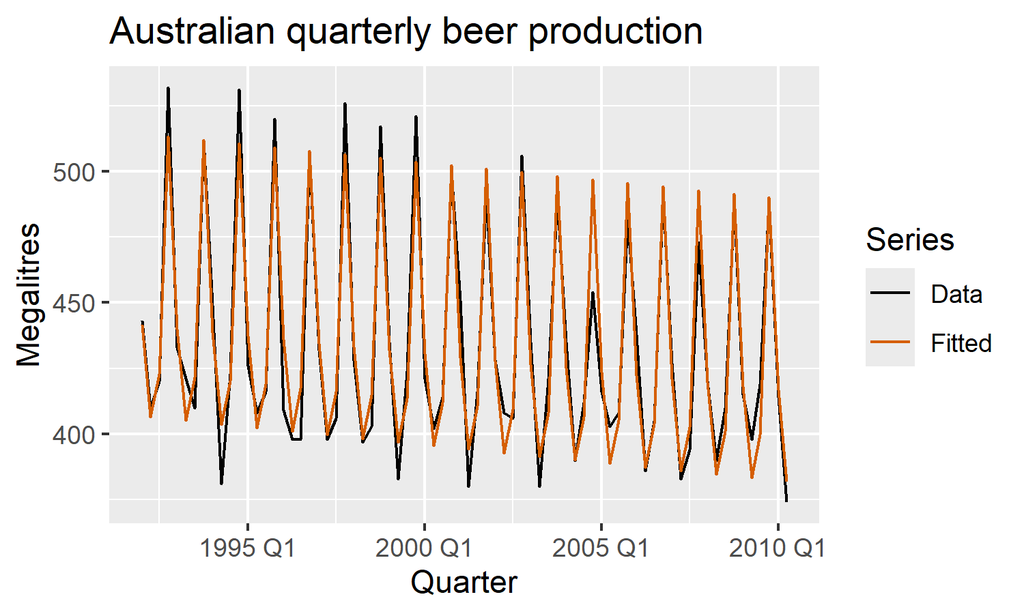

## 호주의 맥주 생산량: 4. 실제값과 적합값 비교

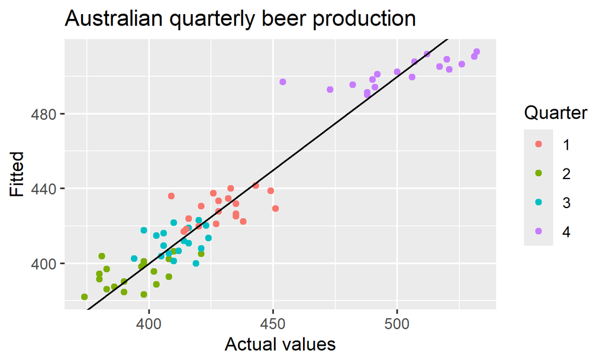

## 개입변수 (Intervention Variables)

## 개입변수

- 시계열 분석에서는 예측대상 변수에 영향을 미치는 **개입(intervention)** 요인을 모형에 반영해야 하는 경우가 자주 발생한다.
  - 예를 들어, **경쟁사 활동**, **광고비 지출**, **산업 파업** 등은 모두 시계열에 일시적 혹은 지속적인 영향을 줄 수 있다.

## 1. 일시적 개입: 스파이크 변수 (Spike Variable)

- 개입의 효과가 **단 한 시점** 동안만 지속된다면 이를 **스파이크 변수(spike variable)** 로 표현할 수 있다.
- 스파이크 변수는 개입이 발생한 시점에만 1을 갖고, 다른 시점에서는 모두 0을 갖는다.
  - 이는 이상치를 처리할 때 사용하는 더미변수와 동일한 방식이다.
- 즉, **짧고 즉각적인 충격 효과** 를 반영하기 위한 변수이다.

## 2. 영구적 개입: 단계 변수 (Step Variable)

- 개입의 효과가 **즉각적이고 영구적** 으로 지속되는 경우, 이를 **단계 변수(step variable)** 로 표현한다.
- 단계 변수는 개입 이전에는 0, 개입이 발생한 시점 이후에는 1을 갖는다.
  - 이는 시계열 수준(level)에 **단계적 변화** 가 발생할 때 사용된다.
- 즉, 개입 이후 시계열이 갑작스럽게 상승하거나 하락한 후 그 수준이 지속될 때를 의미한다.

## 3. 추세 변화: 절편이 아닌 기울기 변화

- 또 다른 형태의 영구적 개입은 **추세의 변화** 이다.
  - 이 경우 개입은 시계열의 **기울기** 를 바꾸게 되며,  
    이를 모델링하기 위해 **구간별 선형 추세** 를 사용한다.
- 이는 개입 시점에서 추세선이 “꺾이는” 형태를 보이게 하며, 결과적으로 **비선형 추세** 를 유도한다.
  - 이러한 기법은 추후에 자세히 다룬다.

## 영업일 변수

- 월별 데이터에서는 해당 월의 **영업일 수** 가 매출 데이터에 상당한 영향을 미칠 수 있다.
- 이를 보정하기 위해, 각 월의 영업일 수를 예측변수로 포함할 수 있다.
- 또는, 요일별 효과를 반영하기 위해 다음과 같은 7개의 예측변수를 둘 수도 있다.

\[ \begin{aligned} x_1 &= \text{해당 월의 월요일 수}, \\ x_2 &= \text{해당 월의 화요일 수}, \\ &\;\vdots \\ x_7 &= \text{해당 월의 일요일 수}. \end{aligned} \]

이렇게 하면 요일별 차이를 모형에 반영할 수 있다.

## 분산시차모형 (Distributed Lags)

- 광고비와 같이 효과가 **시간에 걸쳐 누적**되는 변수는 단순히 현재 시점의 값만으로는 충분하지 않다.
  - 광고 효과가 실제 캠페인 기간 이후에도 지속될 수 있기 때문이다.
- 따라서, 광고비의 **시차(lagged)** 값을 여러 개 포함하는 것이 일반적이다.

\[ \begin{aligned} x_1 &= \text{전월의 광고비 }, \\ x_2 &= \text{2개월 전 광고비 }, \\ &\;\vdots \\ x_m &= \text{\(m\)개월 전 광고비 }. \end{aligned} \]

## 부활절 효과 (Easter Effect)

- **부활절(Easter)** 은 대부분의 공휴일과 달리 매년 같은 날짜에 열리지 않으며, 그 영향이 여러 날에 걸쳐 지속될 수 있다.
  - 우리나라 음력 휴일(설날, 부처님오신날, 추석)도 이에 해당한다.
- 이 경우, 부활절 기간이 포함된 시점에는 1을, 그 외 기간에는 0을 부여하는 **더미변수** 를 사용할 수 있다.
- 월별 데이터의 경우, 부활절이 **3월** 에 속하면 3월에 더미변수 값이 1이 되고, **4월** 에 속하면 4월에 1이 된다.
- 부활절이 **3월에 시작해 4월에 끝나는 경우**, 더미변수의 값은 각 월에 대해 부활절 기간 비율에 따라 **비례적으로 분할** 한다.
- 이렇게 하면 부활절의 시기적 불규칙성이 모델에 반영되어 더 정확한 계절 효과 추정을 할 수 있다.